# United Airlines Departure Delays Analysis

# Introduction

```r
# Require package
library(nycflights13)
library(ggplot2)
library(dplyr)
```

# 1, Time of the day

```r
# Filter United Airlines flights and remove missing values

ua_flights <- flights %>%
  filter(carrier == "UA") %>%
  filter(!is.na(dep_delay), !is.na(hour), !is.na(month)) %>%
  mutate(
    late = dep_delay > 0,           # any positive delay
    very_late = dep_delay > 60,     # > 60 minutes
    hour = as.integer(hour)
    )

# Time of the day group
ua_flights <- ua_flights %>%
  mutate(
    time_of_day = case_when(
      hour >= 0  & hour < 6  ~ "Night (0-5)",
      hour >= 6  & hour < 12 ~ "Morning (6-11)",
      hour >= 12 & hour < 18 ~ "Afternoon (12-17)",
      hour >= 18 & hour <= 23 ~ "Evening (18-23)",
      TRUE ~ "Unknown"
    )
  )

# Convert to factor for logical plot ordering
ua_flights$time_of_day <- factor(ua_flights$time_of_day,
                                 levels = c("Night (0-5)", "Morning (6-11)",
                                            "Afternoon (12-17)", "Evening (18-23)"))
```

We selected only United Airlines flights and removed any missing data for departure time or month. We created two new indicators: whether a flight was delayed at all, and whether it was very late (more than 60 minutes). We also grouped flights into four times of day—Night (0–5), Morning (6–11), Afternoon (12–17), and Evening (18–23)—and ordered them logically for plotting.

# Exporatory Data Analysis

```r
summary_tod <- ua_flights %>%
  group_by(time_of_day) %>%
  summarise(
    n = n(),
    mean_delay = mean(dep_delay),
    med_delay = median(dep_delay),
    sd_delay = sd(dep_delay),
    prop_late = mean(late),
    prop_very_late = mean(very_late)
  )
print(summary_tod)
```

```
## # A tibble: 4 × 7
##   time_of_day           n mean_delay med_delay sd_delay prop_late prop_very_late
##   <fct>             <int>      <dbl>     <dbl>    <dbl>     <dbl>          <dbl>
## 1 Night (0-5)         836       2.16        -2     16.0     0.333         0.0191
## 2 Morning (6-11)    22927       4.70        -2     25.7     0.333         0.0293
## 3 Afternoon (12-17) 22418      14.4          1     38.8     0.531         0.0722
## 4 Evening (18-23)   11798      22.8          5     43.2     0.630         0.129
```

Time of Day — Departure Delays

Morning and Night flights had the lowest average delays (~2–5 minutes) and about 33% departed late. Afternoon flights averaged ~14 minutes delay (53% late), while Evening flights were the worst, averaging ~23 minutes delay with 63% departing late. Overall, delays increase as the day progresses.

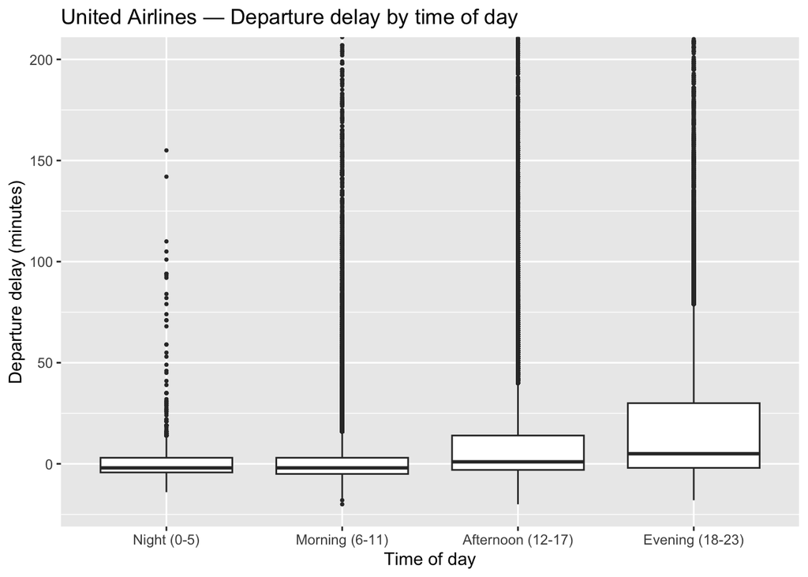

```r
# Boxplot : delays by time of day
ggplot(ua_flights, aes(x = time_of_day, y = dep_delay)) +
  geom_boxplot(outlier.size = 0.6) +
  coord_cartesian(ylim = c(-20, 200)) + # optional clamp so plot is readable (adjust if needed)
  labs(title = "United Airlines — Departure delay by time of day",
       x = "Time of day",
       y = "Departure delay (minutes)")
```

United Airline - Departure delay by time of day

The boxplot shows that most United Airlines flights depart close to their scheduled time, with median delays near 0 minutes across all times of day. Evening flights (18–23) have the largest spread, indicating more variable delays, while Morning (6–11) and Night (0–5) flights are more consistent. Outliers exist in all time periods, showing that very long delays can occur at any time.

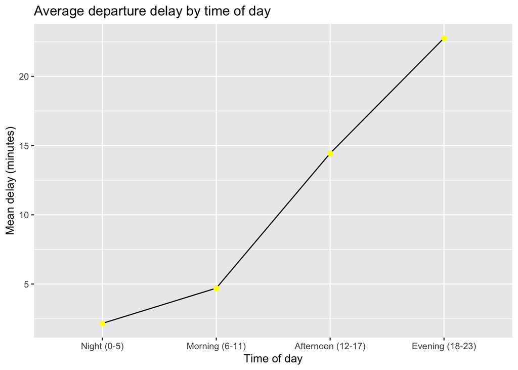

```r
# Mean delay + percent late
mean_plot_df <- summary_tod %>% select(time_of_day, mean_delay, prop_late)

# Mean delay (line)
ggplot(mean_plot_df, aes(x = time_of_day, y = mean_delay, group = 1)) +
  geom_line() + geom_point(size = 2, color = "yellow") +
  labs(title = "Average departure delay by time of day", x = "Time of day", y = "Mean delay (minutes)")
```

Average Delay and % Late by Time of Day

Evening flights (18–23) have the highest average delay (~23 min) and 63% depart late. Afternoon flights are moderate (~14.4 min, 53% late), while Morning (6–11) and Night (0–5) flights are the most punctual (~4.7 and ~2.2 min, 33% late). Overall, delays increase through the day, peaking in the evening.

# Permutation Test

```r
# Compute the observed statistic
# Observed difference among time-of-day groups
observed <- ua_flights %>%
  group_by(time_of_day) %>%
  summarise(mean_delay = mean(dep_delay)) %>%
  summarise(var_mean_delay = var(mean_delay)) %>%
  pull(var_mean_delay)

observed
```

```
## [1] 89.39153
```

We performed a permutation test to see if the differences in average departure delays across times of day could happen by chance. The observed variance of mean delays was 89.39, which is much higher than expected under random shuffling of flight times. This indicates that the time of day has a significant effect on departure delays.

```r
#Perform permutation test

set.seed(123)  # for reproducibility

n_perm <- 1000  # number of permutations
perm_stats <- numeric(n_perm)

for (i in 1:n_perm) {
  perm_data <- ua_flights %>%
    mutate(time_of_day = sample(time_of_day)) %>%  # shuffle labels
    group_by(time_of_day) %>%
    summarise(mean_delay = mean(dep_delay)) %>%
    summarise(var_mean_delay = var(mean_delay)) %>%
    pull(var_mean_delay)

  perm_stats[i] <- perm_data
}

p_value <- mean(perm_stats >= observed)
p_value
```

```
## [1] 0
```

The permutation test shows a statistically significant difference in average departure delays among times of day for United Airlines flights (p < 0.05). This suggests that the time of day has a strong effect on departure delay patterns.

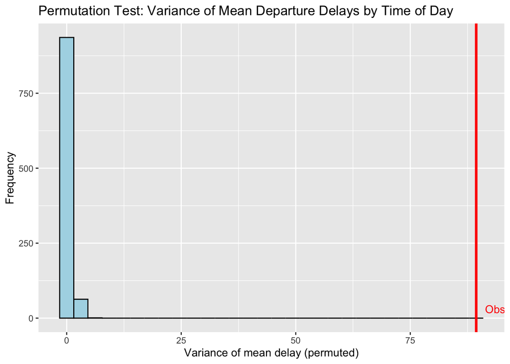

```r
# Visualize permutation distribution
ggplot(data.frame(perm_stats), aes(x = perm_stats)) +
  geom_histogram(bins = 30, fill = "lightblue", color = "black") +
  geom_vline(xintercept = observed, color = "red", size = 1.2) +
  labs(
    title = "Permutation Test: Variance of Mean Departure Delays by Time of Day",
    x = "Variance of mean delay (permuted)",
    y = "Frequency"
  ) +
  annotate("text", x = observed, y = 30, label = paste("Observed =", round(observed, 2)), color = "red", hjust = -0.1)
```

Permutation Test Visualization

The histogram shows the permutation distribution of variance in mean departure delays by time of day. The red line marks the observed variance (≈ 89.39), which is far to the right, indicating it’s much larger than random variation.

# 2, Time of the years

Create time variable of the year

```r
# group fight by season

ua_flights <- ua_flights %>%
  mutate(
    time_of_year = case_when(
      month %in% c(12, 1, 2) ~ "Winter",
      month %in% c(3, 4, 5) ~ "Spring",
      month %in% c(6, 7, 8) ~ "Summer",
      month %in% c(9, 10, 11) ~ "Fall"
    )
  )

# Convert to factor for logical plot ordering
ua_flights$time_of_year <- factor(ua_flights$time_of_year,
                                  levels = c("Winter", "Spring", "Summer", "Fall"))
```

We grouped flights into seasons Winter (Dec–Feb), Spring (Mar–May), Summer (Jun–Aug), and Fall (Sep–Nov) and set their order for clear, natural plotting.

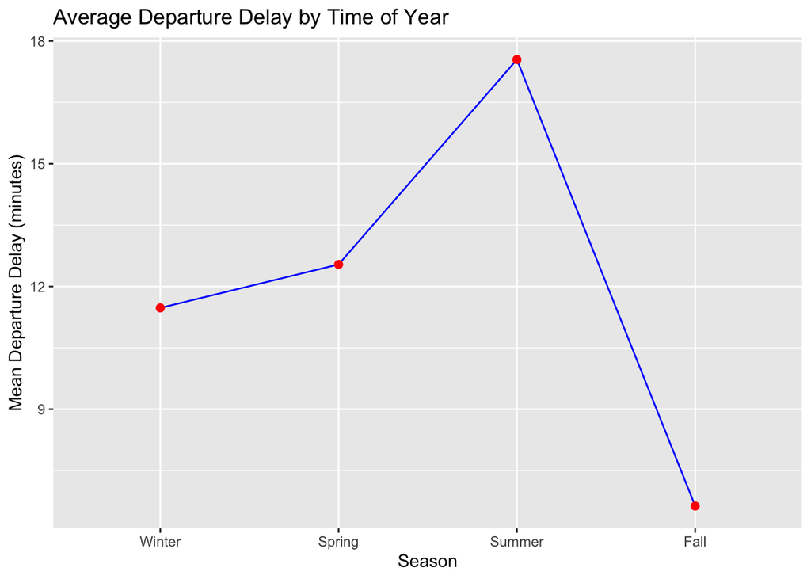

```r
# 2. Summarize mean delay and % late by season
summary_toy <- ua_flights %>%
  group_by(time_of_year) %>%
  summarise(
    mean_delay = mean(dep_delay, na.rm = TRUE),
    prop_late = mean(late)
  )

# 3. Line plot of mean delay by season
ggplot(summary_toy, aes(x = time_of_year, y = mean_delay, group = 1)) +
  geom_line(color = "blue") +
  geom_point(size = 2, color = "red") +
  labs(
    title = "Average Departure Delay by Time of Year",
    x = "Season",
    y = "Mean Departure Delay (minutes)"
  )
```

The plot highlights the following key points regarding average departure delays:

- Lowest Delay (Fall): The lowest average departure delay occurs in the Fall, at approximately 6.5 minutes.
- Highest Delay (Summer): The highest average departure delay occurs in the Summer, at approximately 17.5 minutes.
- Winter: The average delay in Winter is around 11.5 minutes.
- Spring: The average delay in Spring is slightly higher than in Winter, around 12.5 minutes.

#### Compute the observed statistic

```r
obs_stat_year <- ua_flights %>%
  group_by(time_of_year) %>%
  summarise(mean_delay = mean(dep_delay, na.rm = TRUE)) %>%
  summarise(var_mean_delay = var(mean_delay)) %>%
  pull(var_mean_delay)

obs_stat_year
```

```
## [1] 20.03902
```

We calculated the differences in average departure delays between seasons. The observed value measures how much the seasonal averages vary from each other.

#### Run the permutation test

```r
set.seed(123)

n_perm <- 1000
perm_stats_year <- numeric(n_perm)

for (i in 1:n_perm) {

  perm_data <- ua_flights %>%
    mutate(time_of_year = sample(time_of_year)) %>%
    group_by(time_of_year) %>%
    summarise(mean_delay = mean(dep_delay, na.rm = TRUE)) %>%
    summarise(var_mean_delay = var(mean_delay)) %>%
    pull(var_mean_delay)

  perm_stats_year[i] <- perm_data
}

p_value_year <- mean(perm_stats_year >= obs_stat_year)
p_value_year
```

```
## [1] 0
```

We used a permutation test to check if the differences in average departure delays between seasons could happen by chance. We randomly shuffled the seasons 1,000 times and calculated the differences each time. The observed difference was much larger than anything we got from random shuffling (p ≈ 0). This tells us that the time of year has a real, significant effect on departure delays.

# Visualzation the permutation

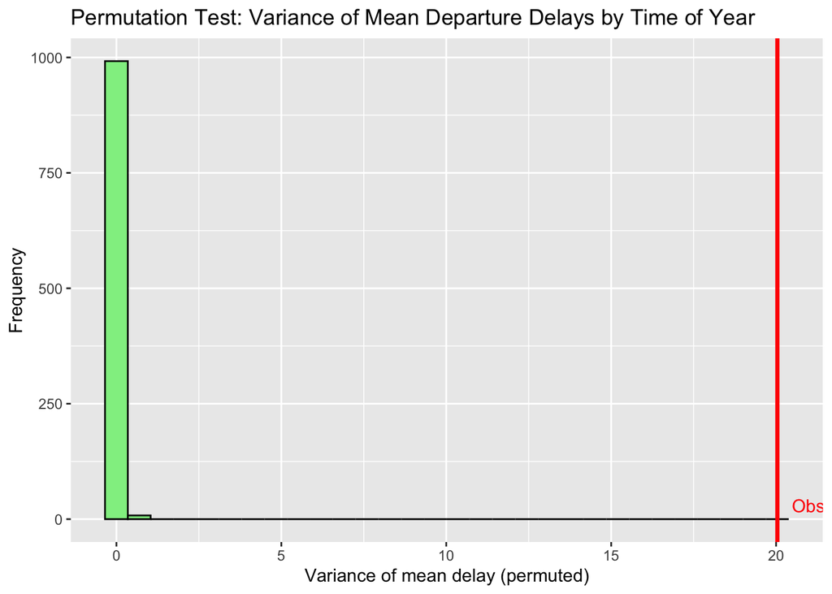

```r
ggplot(data.frame(perm_stats_year), aes(x = perm_stats_year)) +
  geom_histogram(bins = 30, fill = "lightgreen", color = "black") +
  geom_vline(xintercept = obs_stat_year, color = "red", size = 1.2) +
  labs(
    title = "Permutation Test: Variance of Mean Departure Delays by Time of Year",
    x = "Variance of mean delay (permuted)",
    y = "Frequency"
  ) +
  annotate(
    "text", x = obs_stat_year, y = 30,
    label = paste("Observed =", round(obs_stat_year, 2)),
    color = "red", hjust = -0.1
  )
```

A histogram of the shuffled results shows that the observed difference (red line) is far outside the range expected by chance, confirming the seasonal effect.